# Data Wrangling Strategies with R

Clay Ford

Summer 2022

# Agenda

Cover the following topics with examples and exercises:

- Understanding lists
- Working with dates
- Working with character data
- Binding data frames
- Merging or Joining data frames
- Reshaping data frames

# Data structures in R: vector

Vector: 1D object of same data type (eg, all numeric, or all character). Like a column of data in a spreadsheet

```r
x <- c(1, 4, 7, 11)
x
```

```
## [1]  1  4  7 11
```

# Data structures in R: data frame

data frame: 2D object consisting of vectors of the same length but of potentially different data types

```r
x <- c(1, 3, 5)
g <- c("M", "M", "F")
df <- data.frame(x, g)
df
```

```
##   x g
## 1 1 M
## 2 3 M
## 3 5 F
```

Notice `x` is numeric while `g` is character.

# Data structures in R: lists

list: the most general data structure. It can contain vectors, data.frames, and other lists. When data wrangling, we sometimes need to work with lists at an intermediate step.

```r
lst <- list(x = 5, df = data.frame(x, g))
lst
```

```
## $x
## [1] 5
##
## $df
##   x g
## 1 1 M
## 2 3 M
## 3 5 F
```

# Applying functions to elements in a list

The `lapply` function allows us to *apply* functions to elements of a list. Example: Find the mean of each list element

```r
(lst <- list(y1 = 1:4, y2 = 6:10))
```

```
## $y1
## [1] 1 2 3 4
##
## $y2
## [1]  6  7  8  9 10
```

```r
lapply(lst, mean)
```

```
## $y1
## [1] 2.5
##
## $y2
## [1] 8
```

# Dates and Date-times in R

- When a date (eg, April 5, 1982) is formatted as a “date” in R, it becomes the number of days after (or before) January 1, 1970.
- When a date-time (eg, April 5, 1982 1:15 PM) is formatted as a “date-time”, it becomes the number of seconds after (or before) January 1, 1970.
- This allows the calculation of time spans.
- The `lubridate` package helps us parse dates and date-times as well as perform calculations and conversions of such values.

# Parsing dates

- `lubridate` provides a series of functions for parsing dates that are a permutation of the letters “m”, “d” and “y” to represent the ordering of month, day and year.
- `lubridate` provides functions for every permutation of “m”, “d”, “y”.

```r
library(lubridate)
d <- "April 5, 1982"
d <- mdy(d)
d
```

```
## [1] "1982-04-05"
```

# Printed values vs. stored values

- A date that is parsed with `lubridate` will print to the console and appear in data frames as if it’s character data.
- Use `as.numeric` to see the stored value.

```r
d
```

```
## [1] "1982-04-05"
```

```r
as.numeric(d) # days since 1/1/1970
```

```
## [1] 4477
```

# Parsing date-times

To parse date-times, append either `_h`, `_hm`, or `_hms` to the “mdy” function.

```r
d <- "April 5, 1982 1:15 PM"
d <- mdy_hm(d)
d
```

```
## [1] "1982-04-05 13:15:00 UTC"
```

```r
as.numeric(d) # seconds since 1/1/1970
```

```
## [1] 386860500
```

# Parsing times

`lubridate` also allows us to parse hours, minutes and seconds using `hm`, `ms` and `hms`

```r
t <- c("1:23","2:34")
hm(t)
```

```
## [1] "1H 23M 0S" "2H 34M 0S"
```

```r
ms(t)
```

```
## [1] "1M 23S" "2M 34S"
```

The output is nicely formatted, but these are stored as seconds

# Extracting date components

`lubridate` provides functions such as `month`, `day`, `wday`, `yday`, etc. to extract date components

```r
d <- mdy("5/5/01")
month(d, label = TRUE) # month
```

```
## [1] May
## 12 Levels: Jan < Feb < Mar < Apr < May < Jun < Jul < Aug < Sep < ... < Dec
```

```r
wday(d, label = TRUE) # week day
```

```
## [1] Sat
## Levels: Sun < Mon < Tue < Wed < Thu < Fri < Sat
```

# Character strings

Our data often include character strings such as names, locations, descriptions, categories or unwanted “junk”. Examples of manipulating character strings include…

- Converting text to UPPERCASE or lowercase
- Extract parts of a string (Eg, extract “`23`” from “`<b>23</b>`”)
- Padding strings with zeroes, so 9, 10, 11 become 009, 010, 011
- Identify patterns of text for purpose of extracting, replacing or subsetting data

We will use the `stringr` package to work with character strings.

# Character data in R

- Character data have quotes when printed to console
- But data with quotes does not mean it’s character!
- use `is.character()` to find out.
- Character data need to be surrounded with quotes (either single or double) when used in `R` code

```r
(x <- c("a","b","c","12"))
```

```
## [1] "a"  "b"  "c"  "12"
```

```r
is.character(x)
```

```
## [1] TRUE
```

# Character versus factor

- Sometimes data that appear to be character are actually stored as a *factor*
- Factors are character data that are stored as integers but have character labels
- Factors are good for using character data in statistical modeling (eg, ANOVA, regression, etc)
- If your character data is stored as a factor, R automatically handles conversion to dummy matrices necessary for statistical modeling routines
- Factors do not have quotes when printed to console

# Factor data in R

```r
(y <- factor(c("a","b","c","c")))
```

```
## [1] a b c c
## Levels: a b c
```

```r
is.character(y)
```

```
## [1] FALSE
```

# When to convert factors to character

- If you plan to clean or manipulate character data, make sure it’s character, not factor.
- Change factor to character with `as.character` function

```r
(y <- factor(c("a","b","c","c")))
```

```
## [1] a b c c
## Levels: a b c
```

```r
(y <- as.character(y))
```

```
## [1] "a" "b" "c" "c"
```

# Convert case of string

- `str_to_upper`, `str_to_lower`, and `str_to_title` do what you expect

```r
library(stringr)
str_to_upper("day one")
```

```
## [1] "DAY ONE"
```

```r
str_to_lower("DAY ONE")
```

```
## [1] "day one"
```

```r
str_to_title("day one")
```

```
## [1] "Day One"
```

# find-and-remove within strings

- `str_remove` finds first occurrence of specified pattern and removes it

```r
# find first - and replace with nothing
str_remove("434-555-1212", "-")
```

```
## [1] "434555-1212"
```

- `str_remove_all` finds all occurrences of specified pattern and removes it

```r
# find all - and replace with nothing
str_remove_all("434-555-1212", "-")
```

```
## [1] "4345551212"
```

# find-and-replace within strings

- `str_replace` finds first occurrence of specified pattern and replaces with specified text

```r
str_replace("434-555-1212", "-", ".")
```

```
## [1] "434.555-1212"
```

- `str_replace_all` finds all occurrences of specified pattern and replaces with specified text

```r
str_replace_all("434-555-1212", "-", ".")
```

```
## [1] "434.555.1212"
```

# Pad a string with characters

- `str_pad` will pad a string with characters. This is useful for zip codes or ID numbers.
- Specify the width, the side of the padding, and what to pad with.

```r
(zips <- c(22904, 06443, 01331))
```

```
## [1] 22904  6443  1331
```

```r
str_pad(zips, width = 5, side = "left", pad = "0")
```

```
## [1] "22904" "06443" "01331"
```

# Regular Expressions

- Regular expressions are a language for describing text patterns (eg: email addresses, social security numbers, html tags)
- A regular expression is usually formed with some combination of *literal characters*, *character classes* and *modifiers*
  - literal character example: `state` (looking for `"state"`)
  - character class example: `[0-9]` (any number 0 - 9)
  - modifier example: `+` (1 or more of whatever it follows)
- Regular expression example: `state[0-9]+` finds patterns such as `state1`, `state12`, `state99` but not `state`
- We will cover just the basics today as they work in R

# Character classes

- `[0-9]`, `[a-z]`, `[A-Z]`
- Define your own: `[0-3a-g]`, `[AEIOUaeiou]`
- Predefined character classes
  - `[:alpha:]` all letters
  - `[:digit:]` numbers 0 - 9
  - `[:alnum:]` Alphanumeric characters (alpha and digit)
  - `[:blank:]` Blank characters: space and tab
  - `[:lower:]` lowercase letters
  - `[:upper:]` UPPERCASE letters
  - `[:punct:]` Punctuation characters
  - `[:print:]` Printable characters: [:alnum:], [:punct:] and space
  - `[:space:]` Space characters: tab, newline, vertical tab, form feed, carriage return, space

# Modifiers

- `^` start of string; or negation inside character class
- `$` end of string
- `.` any character except new line
- `*` 0 or more
- `+` 1 or more
- `?` 0 or 1
- `|` or (alternative patterns)
- `{}` quantifier brackets: exactly `{n}`; at least `{n,}`; between `{n,m}`
- `()` group patterns together
- `\` escape character (needs to be escaped itself in R! `\\`)
- `[]` character class brackets

Note: precede these with a double backslash if you want to treat them as literal characters.

# Basic regular expression examples

- Remove one or more letters followed by `.` and space at beginning of string

```r
names <- c("Dr. Claibourn","Mr. Ford","Ms. Draber")
str_remove(names, pattern = "^[:alpha:]+\\. ")
```

```
## [1] "Claibourn" "Ford"      "Draber"
```

- Replace “Group”, “grp”, and “group” with “G”

```r
group <- c("Group 1", "grp 1", "group 3")
str_replace(group, "(Group |grp |group )", "G")
```

```
## [1] "G1" "G1" "G3"
```

# Binding data frames

- Row binding: stacking data frames on top of one another
- Column binding: setting data frames next to each other
- Row binding is more common; often used when reading in multiple files of matching structure that need to be combined into one data frame
- Example: importing 10 Excel worksheets for years 2000 - 2009, and then combining into one data frame
- `dplyr` functions: `bind_rows` and `bind_cols`

# Row binding

`bind_rows(data_frame_01, data_frame_02)`

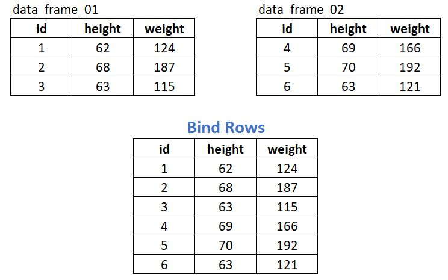

# Column binding

`bind_cols(data_frame_01, data_frame_02)`

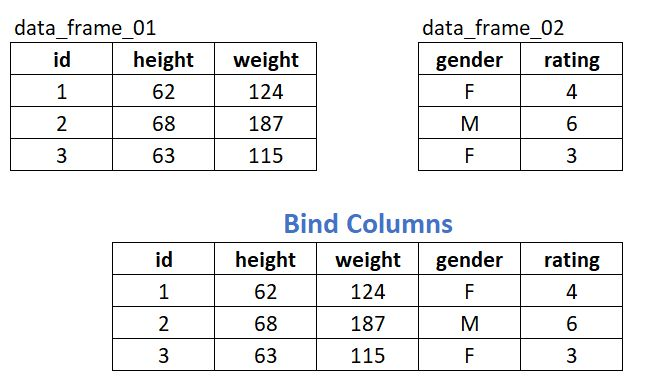

Note: data frames must have the same number of rows.

# Merging or Joining data frames

- Two types of merges, or joins:
  - **Mutating join**: Join data frames based on a common column (or columns), called “keys”
  - **Filtering join**: keep rows in one data frame based on having (or not having) membership in another data frame
- Frequently used to combine two different sources of data.
- Example: merge subject demographic data with subject lab data
- `dplyr` functions:
  - `inner_join`
  - `left_join`
  - `right_join`
  - `full_join`
  - `semi_join`
  - `anti_join`

# Inner Join

Retain only those rows with matching keys in both data sets. `inner_join(band_members,band_instruments,by="name")`

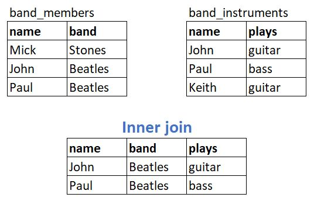

# Left Join

Retain everything in the left data set, merge matches from right. `left_join(band_members,band_instruments,by="name")`

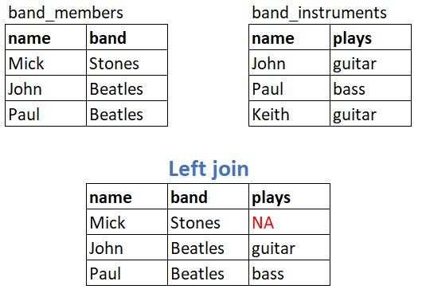

# Right Join

Retain everything in the right data set, merge from left. `right_join(band_members,band_instruments,by="name")`

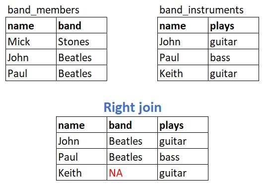

# Full Join

Retain all rows in both data sets. `full_join(band_members,band_instruments,by="name")`

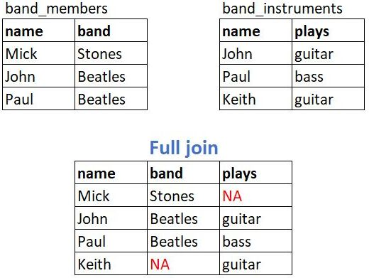

# Semi Join

Retain all rows from left that have matching values in right. `semi_join(band_members,band_instruments,by="name")`

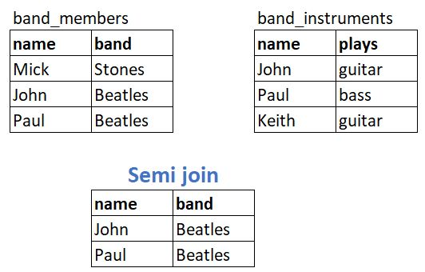

# Anti Join

Retain all rows from left that do NOT have matching values in right. `anti_join(band_members,band_instruments,by="name")`

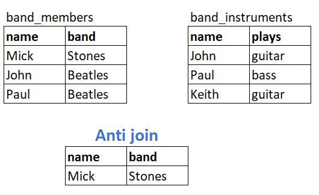

# Reshaping data frames

- Taking column names and making them values in a single column, and vice versa; similiar to transposing data in Excel
- Often expressed as reshaping “wide to long”, or “long to wide”
- Reshaping wide to long is very common in R; often needed to accommodate modeling and plotting functions
- `tidyr` functions: `pivot_longer` (wide to long) and `pivot_wider` (long to wide)

# Reshaping wide to long

Reshape columns week1 - week3 into two columns, one for the column headers (`names_to`) and the other for the values in the columns (`values_to`).

[output not shown]

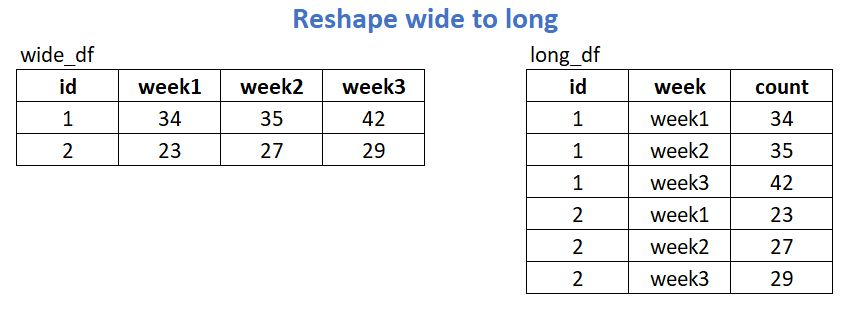

# References

**R for Data Science**: http://r4ds.had.co.nz/

Free online edition of the O’Reilly book *R for Data Science*, by Garrett Grolemund and Hadley Wickham.

The UVA Library also has a physical copy.

# See also

This workshop was previously offered as two workshops, where each went into more detail. Here are links to the materials.

Part 1: bind, merge, reshape  
http://bit.ly/dwr_01

Part 2: dates and strings  
http://bit.ly/dwr_02

# Thanks for coming

- For statistical consulting: statlab@virginia.edu
- Sign up for more workshops or see past workshops: http://data.library.virginia.edu/training/
- Register for the Research Data Services newsletter to be notified of new workshops: http://data.library.virginia.edu/newsletters/